# Heart Attack Prediction Project

Dao Van Duc,Trang Linh To, Khalil Akchi

2025-05-15

# Introduction

Cardiovascular disease remains one of the leading causes of death globally. In this project, we aim to develop a predictive model to estimate the likelihood of a heart attack in patients based on demographic, lifestyle, and medical data. The dataset used consists of over 237,000 patient records and includes information such as age, BMI, general health, smoking status, and prior history of diabetes, angina, or stroke. Using R, we conducted exploratory data analysis (EDA), feature selection, and built two models-logistic regression and random forest-to identify individuals at risk.

# 1. Data Cleaning

## 1.1. Loading Required Packages and Data

```r
library(readxl)
library(dplyr)
data = read_excel('Heart dectection .xlsx')
head(data)
```

```
## # A tibble: 6 × 15
##   PatientID State   Sex    GeneralHealth AgeCategory  HeightInMeters
##       <dbl> <chr>   <chr>  <chr>         <chr>                 <dbl>
## 1         1 Alabama Female Fair          Age 75 to 79           1.63
## 2         2 Alabama Female Very good     Age 65 to 69           1.60
## 3         3 Alabama Male   Excellent     Age 60 to 64           1.78
## 4         4 Alabama Male   Very good     Age 70 to 74           1.78
## 5         5 Alabama Female Good          Age 50 to 54           1.68
## 6         6 Alabama Male   Very good     Age 75 to 79           1.85
## # ℹ 9 more variables: WeightInKilograms <dbl>, BMI <dbl>, HadHeartAttack <dbl>,
## #   HadAngina <dbl>, HadStroke <dbl>, HadDiabetes <chr>, SmokerStatus <chr>,
## #   ChestScan <dbl>, RaceEthnicityCategory <chr>
```

Showing the names of the columns:

```r
colnames(data)
```

```
##  [1] "PatientID"             "State"                 "Sex"
##  [4] "GeneralHealth"         "AgeCategory"           "HeightInMeters"
##  [7] "WeightInKilograms"     "BMI"                   "HadHeartAttack"
## [10] "HadAngina"             "HadStroke"             "HadDiabetes"
## [13] "SmokerStatus"          "ChestScan"             "RaceEthnicityCategory"
```

## 1.2. Data Cleaning

```r
colSums(is.na(data))
```

```
##             PatientID                 State                   Sex
##                     0                     0                     0
##         GeneralHealth           AgeCategory        HeightInMeters
##                     0                     0                     0
##     WeightInKilograms                   BMI        HadHeartAttack
##                     0                     0                     0
##             HadAngina             HadStroke           HadDiabetes
##                     0                     0                     0
##          SmokerStatus             ChestScan RaceEthnicityCategory
##                     0                     0                     0
```

The data do not contains NA value

```r
unique(data$GeneralHealth)
```

```
## [1] "Fair"      "Very good" "Excellent" "Good"      "Poor"
```

General health: Self-reported health status.

```r
unique(data$Sex)
```

```
## [1] "Female" "Male"
```

Sex: gender of the patient

```r
unique(data$AgeCategory)
```

```
##  [1] "Age 75 to 79"    "Age 65 to 69"    "Age 60 to 64"    "Age 70 to 74"
##  [5] "Age 50 to 54"    "Age 80 or older" "Age 55 to 59"    "Age 25 to 29"
##  [9] "Age 40 to 44"    "Age 30 to 34"    "Age 35 to 39"    "Age 18 to 24"
## [13] "Age 45 to 49"
```

Age category : Categorized age group of the patient.

```r
unique(data$SmokerStatus)
```

```
## [1] "Former smoker"
## [2] "Never smoked"
## [3] "Current smoker - now smokes every day"
## [4] "Current smoker - now smokes some days"
```

```r
unique(data$RaceEthnicityCategory)
```

```
## [1] "White only, Non-Hispanic"      "Black only, Non-Hispanic"
## [3] "Other race only, Non-Hispanic" "Multiracial, Non-Hispanic"
## [5] "Hispanic"
```

```r
summary(data)
```

```
##    PatientID         State               Sex            GeneralHealth
##  Min.   :     1   Length:237630      Length:237630      Length:237630
##  1st Qu.: 59408   Class :character   Class :character   Class :character
##  Median :118816   Mode  :character   Mode  :character   Mode  :character
##  Mean   :118816
##  3rd Qu.:178223
##  Max.   :237630
##  AgeCategory        HeightInMeters  WeightInKilograms      BMI
##  Length:237630      Min.   :0.910   Min.   : 28.12    Min.   :12.02
##  Class :character   1st Qu.:1.630   1st Qu.: 68.04    1st Qu.:24.28
##  Mode  :character   Median :1.700   Median : 81.65    Median :27.46
##                     Mean   :1.705   Mean   : 83.67    Mean   :28.69
##                     3rd Qu.:1.780   3rd Qu.: 95.25    3rd Qu.:31.90
##                     Max.   :2.410   Max.   :292.57    Max.   :97.65
##  HadHeartAttack      HadAngina         HadStroke       HadDiabetes
##  Min.   :0.00000   Min.   :0.00000   Min.   :0.00000   Length:237630
##  1st Qu.:0.00000   1st Qu.:0.00000   1st Qu.:0.00000   Class :character
##  Median :0.00000   Median :0.00000   Median :0.00000   Mode  :character
##  Mean   :0.05555   Mean   :0.06151   Mean   :0.04178
##  3rd Qu.:0.00000   3rd Qu.:0.00000   3rd Qu.:0.00000
##  Max.   :1.00000   Max.   :1.00000   Max.   :1.00000
##  SmokerStatus         ChestScan      RaceEthnicityCategory
##  Length:237630      Min.   :0.0000   Length:237630
##  Class :character   1st Qu.:0.0000   Class :character
##  Mode  :character   Median :0.0000   Mode  :character
##                     Mean   :0.4269
##                     3rd Qu.:1.0000
##                     Max.   :1.0000
```

```r
str(data)
```

```
## tibble [237,630 × 15] (S3: tbl_df/tbl/data.frame)
##  $ PatientID            : num [1:237630] 1 2 3 4 5 6 7 8 9 10 ...
##  $ State                : chr [1:237630] "Alabama" "Alabama" "Alabama" "Alabama" ...
##  $ Sex                  : chr [1:237630] "Female" "Female" "Male" "Male" ...
##  $ GeneralHealth        : chr [1:237630] "Fair" "Very good" "Excellent" "Very good" ...
##  $ AgeCategory          : chr [1:237630] "Age 75 to 79" "Age 65 to 69" "Age 60 to 64" "Age 70 to 74" ...
##  $ HeightInMeters       : num [1:237630] 1.63 1.6 1.78 1.78 1.68 ...
##  $ WeightInKilograms    : num [1:237630] 84.8 71.7 71.2 95.2 78 ...
##  $ BMI                  : num [1:237630] 32.1 28 22.5 30.1 27.8 ...
##  $ HadHeartAttack       : num [1:237630] 0 0 0 0 0 0 0 0 0 0 ...
##  $ HadAngina            : num [1:237630] 1 0 0 0 0 0 0 0 0 0 ...
##  $ HadStroke            : num [1:237630] 0 0 0 0 0 0 0 0 0 0 ...
##  $ HadDiabetes          : chr [1:237630] "Yes" "No" "No" "Yes" ...
##  $ SmokerStatus         : chr [1:237630] "Former smoker" "Former smoker" "Never smoked" "Former smoker" ...
##  $ ChestScan            : num [1:237630] 1 0 0 0 1 1 1 0 0 0 ...
##  $ RaceEthnicityCategory: chr [1:237630] "White only, Non-Hispanic" "White only, Non-Hispanic" "White only, Non-Hispanic" "White only, Non-Hispanic" ...
```

Changing categorical variables to factor:

```r
data$Sex <- as.factor(data$Sex)
data$GeneralHealth <- as.factor(data$GeneralHealth)
data$AgeCategory <- as.factor(data$AgeCategory)
data$HadHeartAttack <- as.factor(data$HadHeartAttack)
data$HadAngina <- as.factor(data$HadAngina)
data$HadStroke <- as.factor(data$HadStroke)
data$HadDiabetes <- as.factor(data$HadDiabetes)
data$SmokerStatus <- as.factor(data$SmokerStatus)
data$RaceEthnicityCategory <- as.factor(data$RaceEthnicityCategory)
data$ChestScan <- as.factor(data$ChestScan)
```

We converted categorical variables to factors to ensure proper handling during analysis and modeling.

# 2. Exploratory Data Analysis (EDA)

We define *HadHeartAttack* as the target variable

```r
table(data$HadHeartAttack)
```

```
##
##      0      1
## 224429  13201
```

```r
prop.table(table(data$HadHeartAttack)*100)
```

```
##
##          0          1
## 0.94444725 0.05555275
```

Let’s explore the ditribution of our target variable:

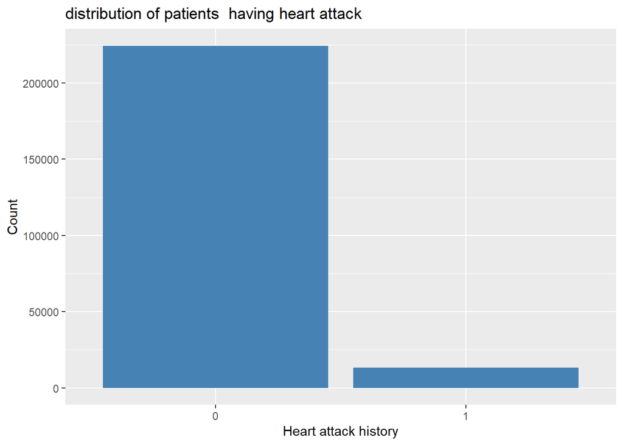

```r
library(ggplot2)
ggplot(data, aes(x = HadHeartAttack)) +
  geom_bar(fill = "steelblue") +
  labs(title = "distribution of patients  having heart attack ",
       x = "Heart attack history", y = "Count")
```

The bar plot shows a strong class imbalance: the number of patients who have never had a heart attack vastly outnumbers those who have. This imbalance (only about 5.5% positive cases) is critical to consider when training classification models, as it may lead to biased predictions unless handled correctly.

Now, we analyze the relationships between target and other *categorical variables*:

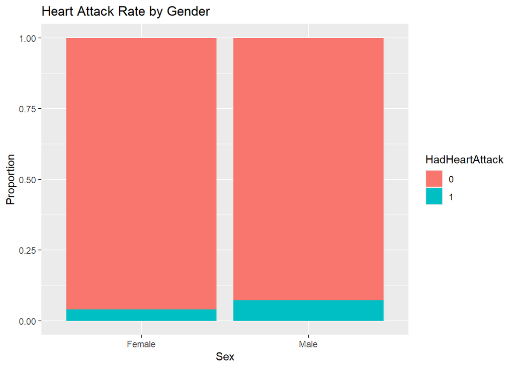

```r
# Analysis by gender
ggplot(data, aes(x = Sex, fill = HadHeartAttack)) +
  geom_bar(position = "fill") +
  labs(title = "Heart Attack Rate by Gender",
       y = "Proportion")
```

The percentage of the male having heart attack is higher than that of the female

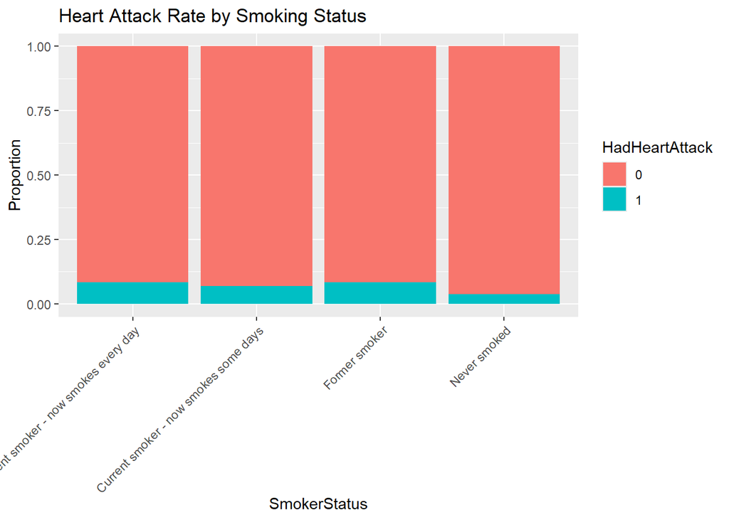

```r
# Analysis by smoking status
ggplot(data, aes(x = SmokerStatus, fill = HadHeartAttack)) +
  geom_bar(position = "fill") +
  labs(title = "Heart Attack Rate by Smoking Status",
       y = "Proportion") +
  theme(axis.text.x = element_text(angle = 45, hjust = 1))
```

Current or former, and especially everyday, smokers appear more likely to report heart attacks than non-smokers, aligning with known cardiovascular risk from tobacco use.

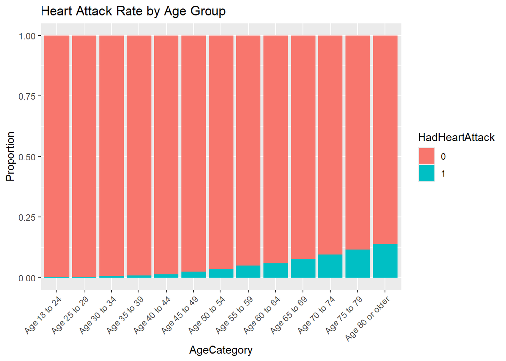

```r
# Analysis by age group
ggplot(data, aes(x = AgeCategory, fill = HadHeartAttack)) +
  geom_bar(position = "fill") +
  labs(title = "Heart Attack Rate by Age Group",
       y = "Proportion") +
  theme(axis.text.x = element_text(angle = 45, hjust = 1))
```

The older a person gets, the more likely they are to develop heart disease.

```r
unique(data$HadDiabetes)
```

```
## [1] Yes
## [2] No
## [3] No, pre-diabetes or borderline diabetes
## [4] Yes, but only during pregnancy (female)
## 4 Levels: No No, pre-diabetes or borderline diabetes ... Yes, but only during pregnancy (female)
```

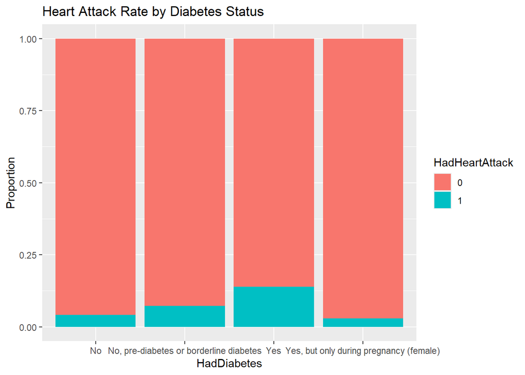

```r
ggplot(data, aes(x = HadDiabetes, fill = HadHeartAttack)) +
  geom_bar(position = "fill") +
  labs(title = "Heart Attack Rate by Diabetes Status",
       y = "Proportion")
```

People with a history of diabetes have a higher percentage risk of developing heart-related diseases

Now we do the Correlation Analysis Between *Numerical Variables*:

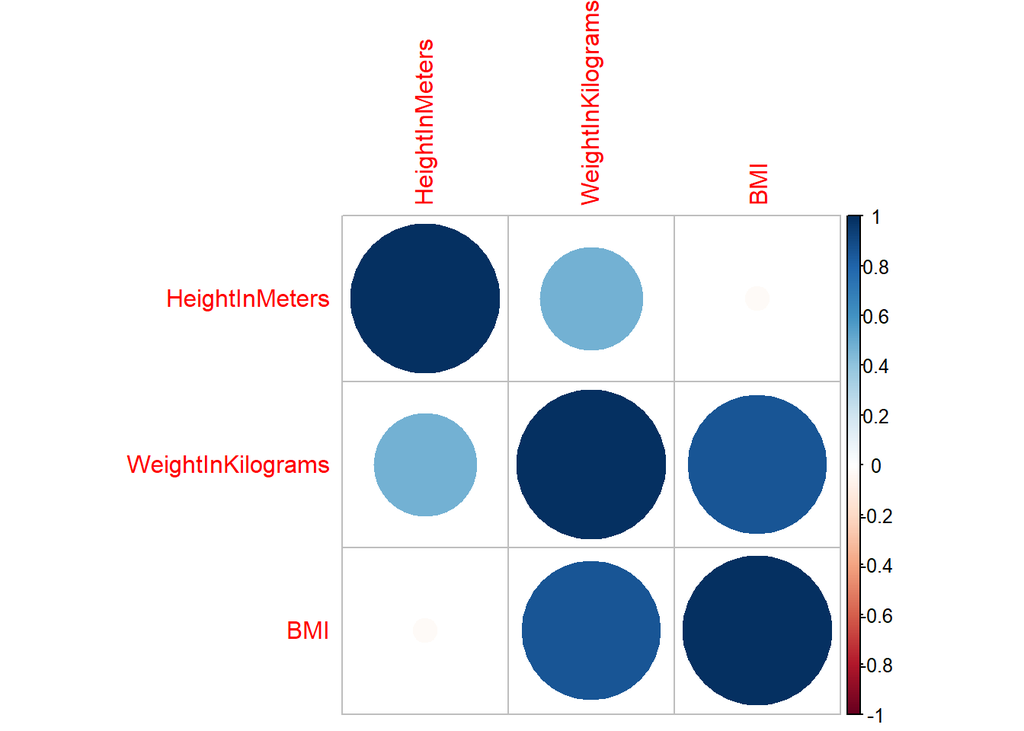

```r
# Select only numerical variables
numeric_vars <- data[, sapply(data, is.numeric)]
numeric_vars <- numeric_vars[, !names(numeric_vars) %in% c("PatientID")]

# Correlation matrix
library(corrplot)
cor_matrix <- cor(numeric_vars, use = "complete.obs")
corrplot(cor_matrix, method = "circle")
```

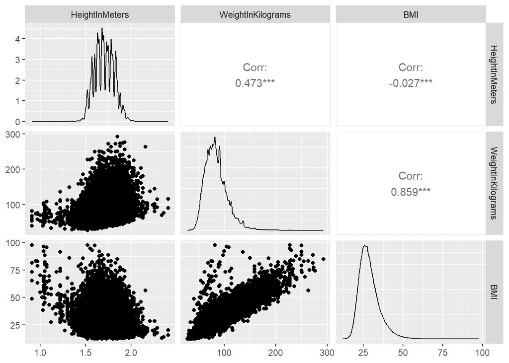

```r
# Pairplot visualization
library(GGally)
ggpairs(numeric_vars)
```

The correlation between BMI and Weightinkilogram is 0.859 => this means BMI and Weight have strong relationship.

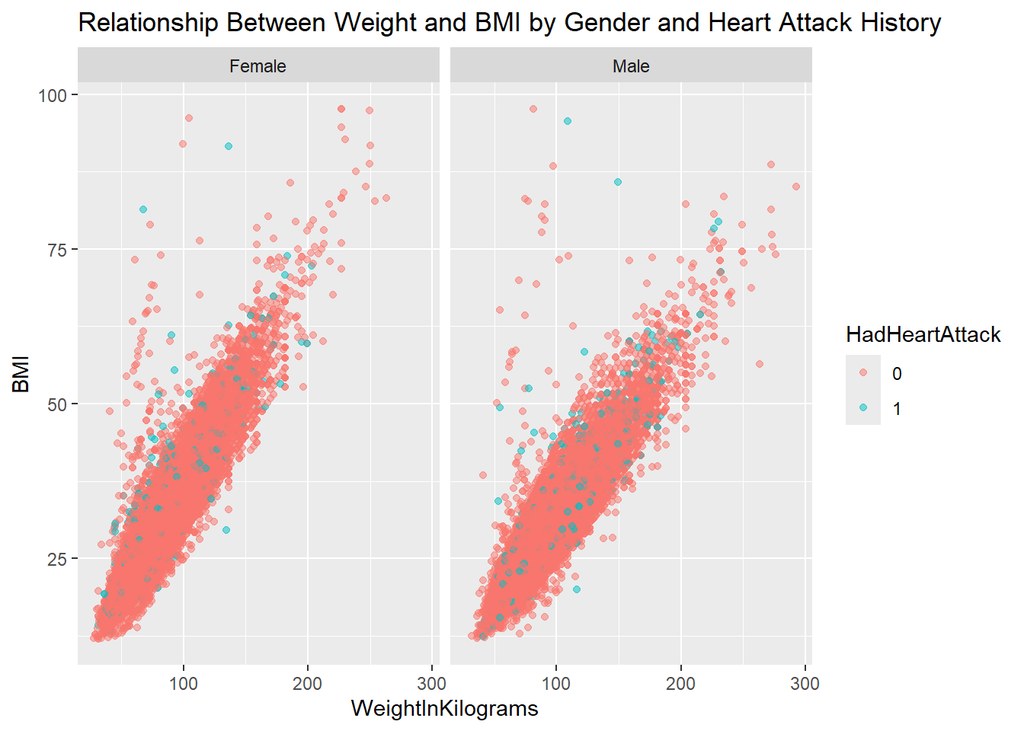

```r
# BMI vs Weight, split by gender and heart attack history
ggplot(data, aes(x = WeightInKilograms, y = BMI, color = HadHeartAttack)) +
  geom_point(alpha = 0.5) +
  facet_wrap(~ Sex) +
  labs(title = "Relationship Between Weight and BMI by Gender and Heart Attack History")
```

```r
# Chi-square test between smoking status and heart attack
chisq.test(data$SmokerStatus, data$HadHeartAttack)
```

```
##
##  Pearson's Chi-squared test
##
## data:  data$SmokerStatus and data$HadHeartAttack
## X-squared = 2166.4, df = 3, p-value < 2.2e-16
```

```r
# Chi-square test between diabetes and heart attack
chisq.test(data$HadDiabetes, data$HadHeartAttack)
```

```
##
##  Pearson's Chi-squared test
##
## data:  data$HadDiabetes and data$HadHeartAttack
## X-squared = 5197, df = 3, p-value < 2.2e-16
```

The X-squared (chi-square) value is 2166.4 There are 3 degrees of freedom (df), suggesting smoking status has 4 categories The p-value is extremely small (< 2.2e-16) Statistical interpretation: There is overwhelming statistical evidence of a strong association between smoking status and heart attacks. The very small p-value (much less than 0.05) indicates this relationship is extremely unlikely to have occurred by chance.

The X-squared value is 5197, which is even higher than the smoking test There are 3 degrees of freedom (df), suggesting diabetes status has 4 categories The p-value is extremely small (< 2.2e-16) Statistical interpretation: There is extremely strong statistical evidence of an association between diabetes and heart attacks. The very high chi-square value and extremely small p-value indicate this relationship is extremely unlikely to be due to chance.

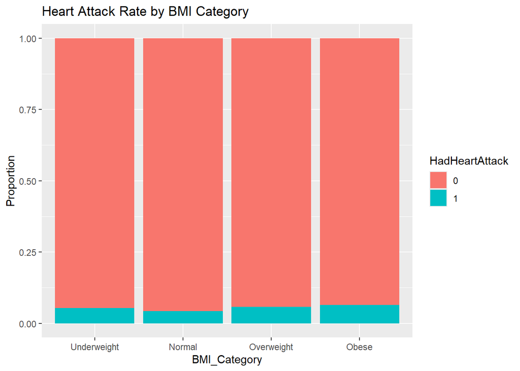

```r
# Create BMI Category variable
data$BMI_Category <- cut(data$BMI,
                         breaks = c(0, 18.5, 25, 30, Inf),
                         labels = c("Underweight", "Normal", "Overweight", "Obese"))

# Analyze heart attack history by BMI group
ggplot(data, aes(x = BMI_Category, fill = HadHeartAttack)) +
  geom_bar(position = "fill") +
  labs(title = "Heart Attack Rate by BMI Category",
       y = "Proportion")
```

There doesn’t seem to be a strong visual trend showing that higher BMI categories have substantially higher heart attack rates. The “Obese” category might have a slightly higher proportion of heart attacks, but the difference appears minimal.

```r
# Creating summary tables
library(tableone)
vars <- c("Age", "Sex", "BMI", "SmokerStatus", "HadDiabetes", "GeneralHealth")
catVars <- c("Sex", "SmokerStatus", "HadDiabetes", "GeneralHealth")
tableOne <- CreateTableOne(vars = vars, strata = "HadHeartAttack",
                           data = data, factorVars = catVars)
print(tableOne, showAllLevels = TRUE)
```

```
##                    Stratified by HadHeartAttack
##                     level                                   0
##   n                                                         224429
##   Sex (%)           Female                                  118437 (52.8)
##                     Male                                    105992 (47.2)
##   BMI (mean (SD))                                            28.64 (6.52)
##   SmokerStatus (%)  Current smoker - now smokes every day    19372 ( 8.6)
##                     Current smoker - now smokes some days     7347 ( 3.3)
##                     Former smoker                            60698 (27.0)
##                     Never smoked                            137012 (61.0)
##   HadDiabetes (%)   No                                      189291 (84.3)
##                     No, pre-diabetes or borderline diabetes   4833 ( 2.2)
##                     Yes                                      28460 (12.7)
##                     Yes, but only during pregnancy (female)   1845 ( 0.8)
##   GeneralHealth (%) Excellent                                39327 (17.5)
##                     Fair                                     26260 (11.7)
##                     Good                                     70451 (31.4)
##                     Poor                                      7283 ( 3.2)
##                     Very good                                81108 (36.1)
##                    Stratified by HadHeartAttack
##                     1             p      test
##   n                 13201
##   Sex (%)            4856 (36.8)  <0.001
##                      8345 (63.2)
##   BMI (mean (SD))   29.50 (6.58)  <0.001
##   SmokerStatus (%)   1776 (13.5)  <0.001
##                       552 ( 4.2)
##                      5495 (41.6)
##                      5378 (40.7)
##   HadDiabetes (%)    8172 (61.9)  <0.001
##                       378 ( 2.9)
##                      4595 (34.8)
##                        56 ( 0.4)
##   GeneralHealth (%)   584 ( 4.4)  <0.001
##                      3705 (28.1)
##                      4499 (34.1)
##                      2001 (15.2)
##                      2412 (18.3)
```

Main conclusion: This table demonstrates that male gender, higher BMI, smoking history, diabetes, and poor general health are significantly associated with heart attack risk.

# 3. Feature Selection and Engineering

In the Exploratory Data Analysis section, we previously examined relationships between variables using both Pearson correlation for numeric features and Chi-square tests for categorical features. These analyses helped identify variables strongly associated with the target outcome (heart attack).

Based on those insights, we now proceed to select the most relevant features for our modeling process. We remove variables that are either: - Highly correlated with one another (multicollinearity), - Irrelevant to heart attack prediction based on prior statistical tests, or - Non-informative, such as IDs or features with near-zero variance.

```r
# Dropping ID column
data_cleaned <- data[, !names(data) %in% c("PatientID")]
```

We remove PatientID because it is an identifier unique to each patient - it doesn’t carry predictive power and can confuse models if left in.

```r
library(caret)
# Identify near-zero variance features
nzv <- nearZeroVar(data_cleaned)

# If any such features exist
if (length(nzv) > 0) {
  # Get their names BEFORE removing them
  removed_features <- names(data_cleaned)[nzv]

  # Remove them from the dataset
  data_cleaned <- data_cleaned[, -nzv]

  # Print removed feature names
  print("Features removed due to near-zero variance:")
  print(removed_features)
} else {
  print("No near-zero variance features found.")
}
```

```
## [1] "Features removed due to near-zero variance:"
## [1] "HadStroke"
```

Variables with little to no variation (e.g., having the same value for most observations) are generally uninformative for predictive modeling and can be removed. The nearZeroVar() function from the caret package is used to detect such features. In our dataset, the column HadStroke was removed because the vast majority of its values were 0, indicating very limited variability. This lack of variation made it statistically redundant for predicting heart attacks.

```r
# Finding highly correlated features (threshold > 0.8)
high_corr <- findCorrelation(cor_matrix, cutoff = 0.8)


# Removing them
if (length(high_corr) > 0) {
  data_cleaned <- data_cleaned[, -high_corr]
  removed_corr_features <- colnames(cor_matrix)[high_corr]
  print("Highly correlated features removed:")
  print(removed_corr_features)
}
```

```
## [1] "Highly correlated features removed:"
## [1] "WeightInKilograms"
```

Feature Selection Justification:

```r
library(rcompanion)
library(reshape2)
```

```r
# Getting only categorical variables
cat_vars <- data_cleaned[, sapply(data_cleaned, is.factor)]

# Computing Cramer's V matrix
cramers_v_matrix <- matrix(NA, ncol = ncol(cat_vars), nrow = ncol(cat_vars))
colnames(cramers_v_matrix) <- rownames(cramers_v_matrix) <- names(cat_vars)

for (i in 1:ncol(cat_vars)) {
  for (j in 1:ncol(cat_vars)) {
    if (i != j) {
      cramers_v_matrix[i, j] <- cramerV(cat_vars[[i]], cat_vars[[j]])
    } else {
      cramers_v_matrix[i, j] <- NA
    }
  }
}

# Printing pairs with Cramer's V > 0.8
which(cramers_v_matrix > 0.8, arr.ind = TRUE)
```

```
##      row col
```

```r
high_corr_indices <- which(cramers_v_matrix > 0.8, arr.ind = TRUE)

# Displaying variable name pairs with high association
apply(high_corr_indices, 1, function(idx) {
  paste(colnames(cat_vars)[idx[1]], "<->", colnames(cat_vars)[idx[2]])
})
```

```
## character(0)
```

No pairs of categorical variables were found to have high correlation (Cramer’s V > 0.8), indicating that all categorical features provide distinct information and can be retained for the modeling phase without concern for redundancy.

# 4. Data Preparation

## 4.1. Data Partitioning and Balancing

Splitting the data:

```r
# Load required package
library(caret)

# Set a seed for reproducibility
set.seed(123)

# Create a partition based on the actual target variable
trainIndex <- createDataPartition(data_cleaned$HadHeartAttack, p = 0.8, list = FALSE)

# Subset the data
train_data <- data_cleaned[trainIndex, ]
test_data <- data_cleaned[-trainIndex, ]
```

The dataset is splitted into training (80%) and testing (20%) sets using ‘HadHeartAttack’ as the target variable.Stratified sampling ensures class distribution is maintained.

```r
sum(train_data$HadHeartAttack==1)
```

```
## [1] 10561
```

```r
sum(train_data$HadHeartAttack==0)
```

```
## [1] 179544
```

```r
sum(test_data$HadHeartAttack==1)
```

```
## [1] 2640
```

```r
sum(train_data$HadHeartAttack==0)
```

```
## [1] 179544
```

Loading libraries:

```r
library(caret)
library(dplyr)
library(ggplot2)
library(pROC)
library(corrplot)
```

## 4.2. Checking Data Distribution Before Processing:

```r
print("\nOriginal data distribution:")
```

```
## [1] "\nOriginal data distribution:"
```

```r
print("Training data:")
```

```
## [1] "Training data:"
```

```r
table(train_data$HadHeartAttack)
```

```
##
##      0      1
## 179544  10561
```

```r
prop.table(table(train_data$HadHeartAttack)) * 100
```

```
##
##         0         1
## 94.444649  5.555351
```

```r
print("\nTest data:")
```

```
## [1] "\nTest data:"
```

```r
table(test_data$HadHeartAttack)
```

```
##
##     0     1
## 44885  2640
```

```r
prop.table(table(test_data$HadHeartAttack)) * 100
```

```
##
##         0         1
## 94.445029  5.554971
```

## 4.3. Applying Downsampling on Training Data:

```r
set.seed(123)
```

Separating training data into majority and minority classes:

```r
majority_class <- train_data[train_data$HadHeartAttack == 0, ]
minority_class <- train_data[train_data$HadHeartAttack == 1, ]

print(paste("Majority class size:", nrow(majority_class)))
```

```
## [1] "Majority class size: 179544"
```

```r
print(paste("Minority class size:", nrow(minority_class)))
```

```
## [1] "Minority class size: 10561"
```

```r
# Random sample from majority class to match minority class size
downsample_majority <- majority_class[sample(nrow(majority_class), nrow(minority_class)), ]

# Combining to create balanced training dataset
balanced_train <- rbind(downsample_majority, minority_class)

# Shuffling the balanced training data
balanced_train <- balanced_train[sample(nrow(balanced_train)), ]

print("Balanced training data distribution:")
```

```
## [1] "Balanced training data distribution:"
```

```r
table(balanced_train$HadHeartAttack)
```

```
##
##     0     1
## 10561 10561
```

```r
prop.table(table(balanced_train$HadHeartAttack)) * 100
```

```
##
##  0  1
## 50 50
```

The training data is imbalanced - very few heart attack cases. We downsampled the majority class to match the minority, creating a balanced training set. This is essential for models to learn both classes equally, though it reduces the total training data size.

# 5. LOGISTIC REGRESSION MODEL

## 5.1. Preparing Data for Logistic Regression Model

Converting target to numeric (0/1) for Logistic Regression:

```r
balanced_train$HadHeartAttack_numeric <- as.numeric(as.character(balanced_train$HadHeartAttack))
test_data$HadHeartAttack_numeric <- as.numeric(as.character(test_data$HadHeartAttack))
```

Creating model formula with all available predictors:

```r
exclude_vars <- c("HadHeartAttack", "HadHeartAttack_numeric", "PatientID","WeightInKilograms")
predictor_vars <- names(balanced_train)[!names(balanced_train) %in% exclude_vars]

formula_string <- paste("HadHeartAttack_numeric ~", paste(predictor_vars, collapse = " + "))
formula <- as.formula(formula_string)

print("Predictors used in the model:")
```

```
## [1] "Predictors used in the model:"
```

```r
print(predictor_vars)
```

```
##  [1] "State"                 "GeneralHealth"         "AgeCategory"
##  [4] "HeightInMeters"        "BMI"                   "HadAngina"
##  [7] "HadDiabetes"           "SmokerStatus"          "ChestScan"
## [10] "RaceEthnicityCategory" "BMI_Category"
```

```r
print(paste("Total number of predictors:", length(predictor_vars)))
```

```
## [1] "Total number of predictors: 11"
```

## 5.2. Fitting Logistic Regression Model

```r
head(balanced_train)
```

```
## # A tibble: 6 × 14
##   State    GeneralHealth AgeCategory     HeightInMeters WeightInKilograms   BMI
##   <chr>    <fct>         <fct>                    <dbl>             <dbl> <dbl>
## 1 New York Very good     Age 60 to 64              1.63              52.2  19.7
## 2 Delaware Fair          Age 70 to 74              1.52              98.4  42.4
## 3 Indiana  Poor          Age 80 or older           1.55              69.8  29.1
## 4 Utah     Good          Age 60 to 64              1.78             108.   34.0
## 5 Alaska   Very good     Age 80 or older           1.73              70.3  23.6
## 6 Guam     Very good     Age 40 to 44              1.52              61.2  26.4
## # ℹ 8 more variables: HadHeartAttack <fct>, HadAngina <fct>, HadDiabetes <fct>,
## #   SmokerStatus <fct>, ChestScan <fct>, RaceEthnicityCategory <fct>,
## #   BMI_Category <fct>, HadHeartAttack_numeric <dbl>
```

```r
logistic_model <- glm(formula, data = balanced_train, family = binomial())

# Display model summary
print("Model Summary:")
```

```
## [1] "Model Summary:"
```

```r
summary(logistic_model)
```

```
##
## Call:
## glm(formula = formula, family = binomial(), data = balanced_train)
##
## Coefficients:
##                                                     Estimate Std. Error z value
## (Intercept)                                        -5.866922   0.449116 -13.063
## StateAlaska                                         0.067158   0.248573   0.270
## StateArizona                                        0.213560   0.222989   0.958
## StateArkansas                                       0.138561   0.244556   0.567
## StateCalifornia                                     0.160062   0.236946   0.676
## StateColorado                                       0.024003   0.232054   0.103
## StateConnecticut                                    0.070559   0.233427   0.302
## StateDelaware                                      -0.265534   0.278938  -0.952
## StateDistrict of Columbia                           0.104070   0.304751   0.341
## StateFlorida                                        0.147216   0.213871   0.688
## StateGeorgia                                       -0.382642   0.228775  -1.673
## StateGuam                                          -0.077023   0.307330  -0.251
## StateHawaii                                         0.174893   0.235077   0.744
## StateIdaho                                          0.312842   0.250944   1.247
## StateIllinois                                      -0.112358   0.268014  -0.419
## StateIndiana                                        0.028925   0.226437   0.128
## StateIowa                                          -0.063743   0.229261  -0.278
## StateKansas                                        -0.279449   0.222286  -1.257
## StateKentucky                                       0.216806   0.257897   0.841
## StateLouisiana                                     -0.009286   0.254076  -0.037
## StateMaine                                          0.281130   0.220569   1.275
## StateMaryland                                      -0.010975   0.212749  -0.052
## StateMassachusetts                                  0.351566   0.235260   1.494
## StateMichigan                                       0.058230   0.224510   0.259
## StateMinnesota                                     -0.040612   0.216462  -0.188
## StateMississippi                                   -0.131064   0.262794  -0.499
## StateMissouri                                      -0.017729   0.239042  -0.074
## StateMontana                                       -0.010181   0.234597  -0.043
## StateNebraska                                       0.204150   0.226545   0.901
## StateNevada                                        -0.157588   0.275030  -0.573
## StateNew Hampshire                                  0.218993   0.237632   0.922
## StateNew Jersey                                    -0.183842   0.245803  -0.748
## StateNew Mexico                                    -0.106212   0.251019  -0.423
## StateNew York                                       0.018144   0.215854   0.084
```

[output cut: 136 more lines]

```
## RaceEthnicityCategoryOther race only, Non-Hispanic  0.12727
## RaceEthnicityCategoryWhite only, Non-Hispanic       0.83605
## BMI_CategoryNormal                                  0.08124 .
## BMI_CategoryOverweight                              0.00929 **
## BMI_CategoryObese                                   0.00586 **
## ---
## Signif. codes:  0 '***' 0.001 '**' 0.01 '*' 0.05 '.' 0.1 ' ' 1
##
## (Dispersion parameter for binomial family taken to be 1)
##
##     Null deviance: 29281  on 21121  degrees of freedom
## Residual deviance: 18450  on 21035  degrees of freedom
## AIC: 18624
##
## Number of Fisher Scoring iterations: 5
```

## 5.3. Evaluation of The Model on Test Data

Making predictions on test data:

```r
predictions <- predict(logistic_model, test_data, type = "response")
predicted_classes <- ifelse(predictions > 0.5, 1, 0)
```

Creating confusion matrix:

```r
confusion_matrix <- confusionMatrix(factor(predicted_classes),
                                   factor(test_data$HadHeartAttack_numeric),
                                   positive = "1")
```

Calculating performance metrics:

```r
accuracy <- confusion_matrix$overall['Accuracy']
sensitivity <- confusion_matrix$byClass['Sensitivity']
specificity <- confusion_matrix$byClass['Specificity']
precision <- confusion_matrix$byClass['Pos Pred Value']
f1_score <- confusion_matrix$byClass['F1']

print("\nModel Performance Metrics:")
```

```
## [1] "\nModel Performance Metrics:"
```

```r
print(paste("Accuracy:", round(accuracy, 4)))
```

```
## [1] "Accuracy: 0.8198"
```

```r
print(paste("Sensitivity (Recall):", round(sensitivity, 4)))
```

```
## [1] "Sensitivity (Recall): 0.7652"
```

```r
print(paste("Specificity:", round(specificity, 4)))
```

```
## [1] "Specificity: 0.8231"
```

```r
print(paste("Precision:", round(precision, 4)))
```

```
## [1] "Precision: 0.2028"
```

```r
print(paste("F1 Score:", round(f1_score, 4)))
```

```
## [1] "F1 Score: 0.3206"
```

Creating ROC curve:

```r
roc_obj <- roc(test_data$HadHeartAttack_numeric, predictions)
auc_value <- auc(roc_obj)

print(paste("AUC:", round(auc_value, 4)))
```

```
## [1] "AUC: 0.8811"
```

Plotting ROC curve:

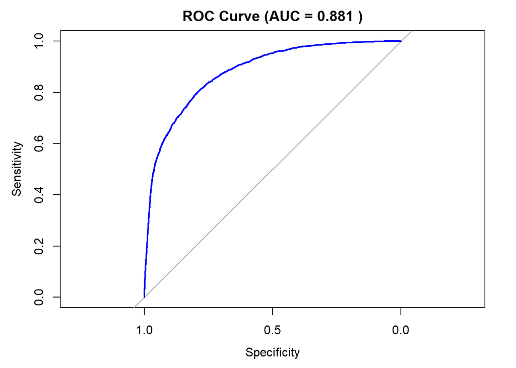

```r
plot(roc_obj, main = paste("ROC Curve (AUC =", round(auc_value, 3), ")"),
     col = "blue", lwd = 2)
```

Confusion matrix:

```r
# Print detailed confusion matrix
print("=== FINAL RESULTS ===")
```

```
## [1] "=== FINAL RESULTS ==="
```

```r
print("Detailed Confusion Matrix:")
```

```
## [1] "Detailed Confusion Matrix:"
```

```r
print(confusion_matrix)
```

```
## Confusion Matrix and Statistics
##
##           Reference
## Prediction     0     1
##          0 36943   620
##          1  7942  2020
##
##                Accuracy : 0.8198
##                  95% CI : (0.8164, 0.8233)
##     No Information Rate : 0.9445
##     P-Value [Acc > NIR] : 1
##
##                   Kappa : 0.2552
##
##  Mcnemar's Test P-Value : <2e-16
##
##             Sensitivity : 0.76515
##             Specificity : 0.82306
##          Pos Pred Value : 0.20277
##          Neg Pred Value : 0.98349
##              Prevalence : 0.05555
##          Detection Rate : 0.04250
##    Detection Prevalence : 0.20962
##       Balanced Accuracy : 0.79411
##
##        'Positive' Class : 1
##
```

```r
print("=== MODEL PERFORMANCE SUMMARY ===")
```

```
## [1] "=== MODEL PERFORMANCE SUMMARY ==="
```

```r
print(paste("- AUC:", round(auc_value, 4)))
```

```
## [1] "- AUC: 0.8811"
```

```r
print(paste("- Accuracy:", round(accuracy, 4)))
```

```
## [1] "- Accuracy: 0.8198"
```

```r
print(paste("- Sensitivity:", round(sensitivity, 4)))
```

```
## [1] "- Sensitivity: 0.7652"
```

```r
print(paste("- Specificity:", round(specificity, 4)))
```

```
## [1] "- Specificity: 0.8231"
```

```r
print(paste("- Precision:", round(precision, 4)))
```

```
## [1] "- Precision: 0.2028"
```

```r
print(paste("- F1 Score:", round(f1_score, 4)))
```

```
## [1] "- F1 Score: 0.3206"
```

# 6. Random Forest Model

## 6.1. Preparing Data for Random Forest Model

The Random Forest model was also implemented and showed good results, potentially offering an alternative to logistic regression in this case:

```r
library(randomForest)
library(caret)
```

```r
train_vars <- names(balanced_train)[!names(balanced_train) %in% c("HadHeartAttack", "HadHeartAttack_numeric")]
train_x <- balanced_train[, train_vars]
train_y <- factor(balanced_train$HadHeartAttack_numeric, levels = c(0, 1), labels = c("No", "Yes"))

test_x <- test_data[, train_vars]
test_y <- factor(test_data$HadHeartAttack_numeric, levels = c(0, 1), labels = c("No", "Yes"))
```

## 6.2. Fitting Random Forest Model

Training Random Forest with class weights:

```r
# Simple Random Forest without sampsize specification
rf_model <- randomForest(x = train_x,
                        y = train_y,
                        ntree = 500,
                        mtry = sqrt(ncol(train_x)),
                        classwt = c(1, 3), # Keep class weights
                        importance = TRUE)
```

Making predictions:

```r
rf_pred <- predict(rf_model, test_x)
rf_prob <- predict(rf_model, test_x, type = "prob")[,2]
```

## 6.3. Evaluation of The Model on Test Data

```r
rf_cm <- confusionMatrix(rf_pred, test_y, positive = "Yes")
rf_roc <- roc(as.numeric(test_y)-1, rf_prob)
print(rf_cm)
```

```
## Confusion Matrix and Statistics
##
##           Reference
## Prediction    No   Yes
##        No  33652   506
##        Yes 11233  2134
##
##                Accuracy : 0.753
##                  95% CI : (0.7491, 0.7569)
##     No Information Rate : 0.9445
##     P-Value [Acc > NIR] : 1
##
##                   Kappa : 0.1916
##
##  Mcnemar's Test P-Value : <2e-16
##
##             Sensitivity : 0.80833
##             Specificity : 0.74974
##          Pos Pred Value : 0.15965
##          Neg Pred Value : 0.98519
##              Prevalence : 0.05555
##          Detection Rate : 0.04490
##    Detection Prevalence : 0.28126
##       Balanced Accuracy : 0.77904
##
##        'Positive' Class : Yes
##
```

```r
print(paste("AUC:", auc(rf_roc)))
```

```
## [1] "AUC: 0.86969149695687"
```

### 6.3.1. Key Performance Metrics

### Overall Accuracy

- **Accuracy: 0.753 (95% CI: 0.7491, 0.7569)**
  - The model correctly predicts about 75.3% of all cases.
  - The narrow 95% confidence interval indicates that the accuracy estimate is quite stable.

### Detection of Positive Cases (Heart Attack Risk)

- **Sensitivity (Recall): 0.80833**
  - The model detects approximately 80.8% of actual heart attack risk cases.
  - This is a good rate, particularly important in healthcare where missing positive cases can have serious consequences.
- **Specificity: 0.74974**
  - The model correctly identifies about 75% of cases without heart attack risk.
- **Positive Predictive Value (Precision): 0.15965**
  - Only about 16% of cases predicted to have heart attack risk are actually positive.
  - This metric is relatively low, indicating the model generates many false positive alerts.
- **AUC: 0.8697**
  - The area under the ROC curve is nearly 0.87, showing good discrimination ability between classes.
  - This important overall evaluation metric indicates the model performs quite well.

## 6.3.2. Confusion Matrix

```
Reference
Prediction   No   Yes
        No  33652 506
        Yes 11233 2134
```

- **True Negatives (TN): 33,652** - Correctly predicted no heart attack risk
- **False Positives (FP): 11,233** - Incorrectly predicted heart attack risk (false positives)
- **False Negatives (FN): 506** - Incorrectly predicted no heart attack risk (false negatives)
- **True Positives (TP): 2,134** - Correctly predicted heart attack risk

## 6.3.3. Model Evaluation

### Strengths

1. **High Sensitivity (0.81)**: The model detects most cases with actual heart attack risk, which is critical in medical contexts.
2. **High AUC (0.87)**: Demonstrates good discrimination ability between classes.
3. **High Balanced Accuracy (0.779)**: The average of sensitivity and specificity shows the model performs well on both classes.
4. **High Negative Predictive Value (0.985)**: When the model predicts no heart attack risk, this prediction is reliable in about 98.5% of cases.

### Weaknesses

1. **Low Precision (0.16)**: Only about 16% of heart attack risk alerts are accurate, leading to many false alarms.
2. **Low Kappa (0.19)**: The Kappa statistic measures agreement between predictions and actual values, accounting for chance. This value is relatively low, suggesting the model is only slightly better than random prediction.
3. **Low Detection Rate (0.045)**: The proportion of correctly identified positive cases in the total sample is low.

### Feature importance

```r
importance(rf_model)
```

```
##                                No        Yes MeanDecreaseAccuracy
## State                  -0.4161568  -2.687991            -2.133735
## GeneralHealth          66.4662675  44.348760            79.154638
## AgeCategory            87.5580152  62.457988           108.950315
## HeightInMeters          3.1811635  39.787571            35.242507
## WeightInKilograms       1.8423833  60.036556            51.418525
## BMI                    -1.3631030  53.271887            46.115533
## HadAngina             231.5507929 183.981018           268.742638
## HadDiabetes            42.4250790   4.241458            41.003248
## SmokerStatus           17.9494926  23.582301            29.284839
## ChestScan              67.3066085  57.088371            83.922684
## RaceEthnicityCategory  -3.0255551   8.394048             3.194418
## BMI_Category           -1.4838049  25.662380            25.105007
##                       MeanDecreaseGini
## State                         783.2370
## GeneralHealth                 570.0864
## AgeCategory                  1286.1831
## HeightInMeters                574.6850
## WeightInKilograms             743.0749
## BMI                           863.5998
## HadAngina                    1015.9313
## HadDiabetes                   228.1265
## SmokerStatus                  274.4319
## ChestScan                     526.7665
## RaceEthnicityCategory         225.9477
## BMI_Category                  121.2427
```

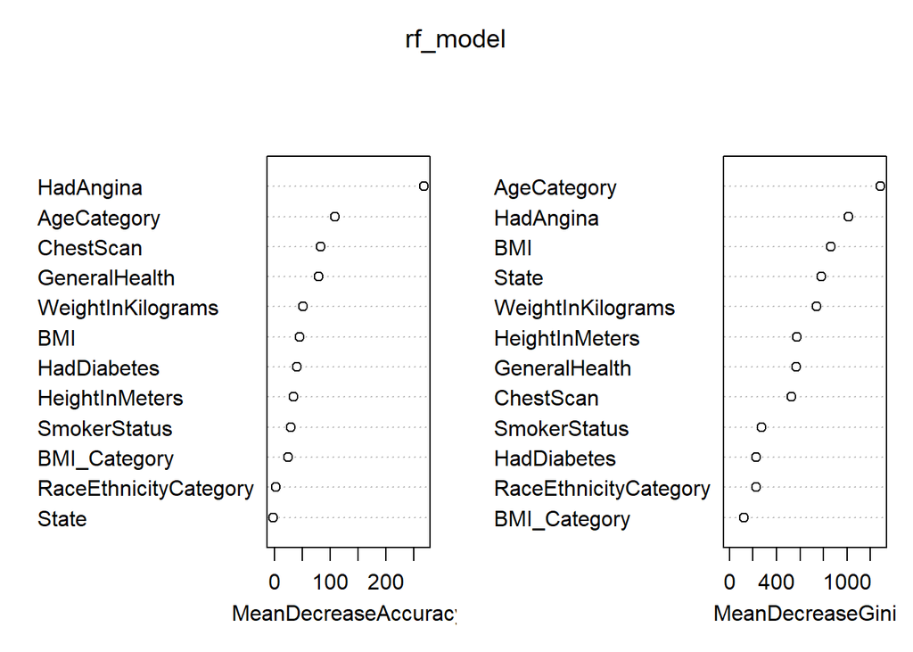

```r
varImpPlot(rf_model)
```

# Conclusion

In this project, we built and evaluated two models - logistic regression and random forest - to predict heart attack risk using a dataset of over 230,000 patient records. Both models performed well, with AUC scores above 0.87, indicating strong discriminatory power.

Logistic Regression offered better overall accuracy (81.9%) and interpretability but lower sensitivity compared to the random forest.

Random Forest achieved higher sensitivity (80.8%), detecting more true positives, though at the cost of precision (16%).

Across both models, consistent key predictors emerged: general health, age, diabetes, angina, BMI, and smoking status.

However, low precision in both models indicates a high false positive rate - largely due to the imbalanced nature of the test set. Future improvements may include:

- Trying advanced balancing techniques (e.g., SMOTE, ROSE).
- Hyperparameter tuning.
- Using ensemble approaches or cost-sensitive learning.
- External validation to test generalizability.

*Overall*, this model offers valuable insights for screening and early risk detection but should be used alongside clinical judgment in practice.